# UTS Regression Models

# Soal I

## Langkah 1

## Membuat Correlation Matrix

```r
suppressPackageStartupMessages({
 library(ggplot2)
  library(corrplot)
  library(readr)
  library(dplyr)
})

data <- read_csv("HeatingOil.csv") # Mengimpor dataset HeatingOil.csv ke dalam variabel 'data'
cor_matrix <- cor(data)
print(cor_matrix) #menghitung matriks korelasi dari seluruh kolom numerik dalam data bernama data.
```

```
##                Insulation Temperature Heating_Oil Num_Occupants     Avg_Age
## Insulation     1.00000000 -0.79369606  0.73609688   -0.01256684  0.64298171
## Temperature   -0.79369606  1.00000000 -0.77365974    0.01251864 -0.67257949
## Heating_Oil    0.73609688 -0.77365974  1.00000000   -0.04163508  0.84789052
## Num_Occupants -0.01256684  0.01251864 -0.04163508    1.00000000 -0.04803415
## Avg_Age        0.64298171 -0.67257949  0.84789052   -0.04803415  1.00000000
## Home_Size      0.20071164 -0.21393926  0.38119082   -0.02253438  0.30655725
##                 Home_Size
## Insulation     0.20071164
## Temperature   -0.21393926
## Heating_Oil    0.38119082
## Num_Occupants -0.02253438
## Avg_Age        0.30655725
## Home_Size      1.00000000
```

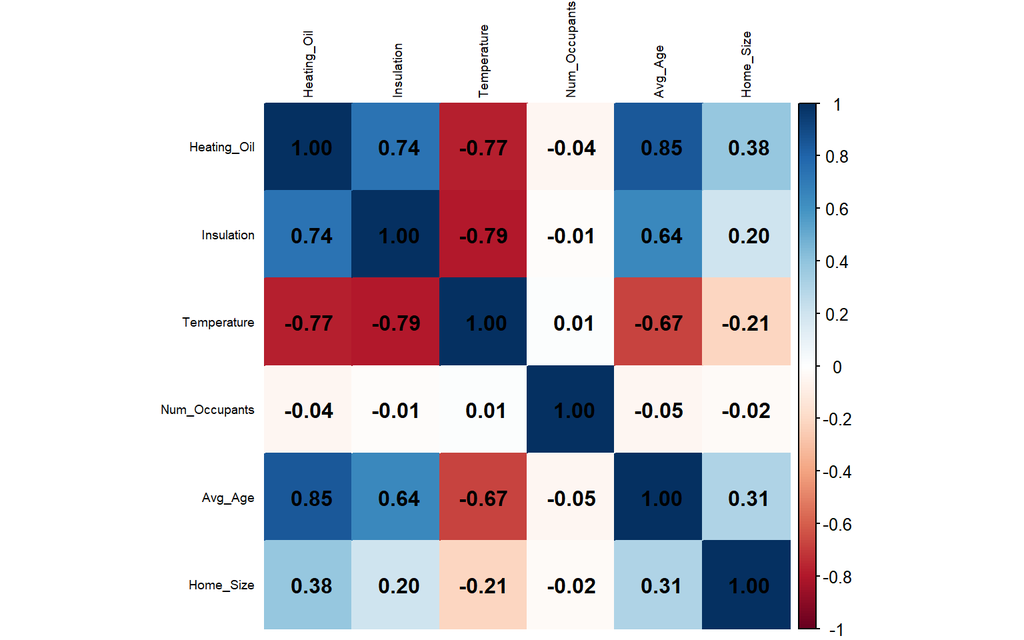

```r
cor_data <- data %>%
  select(Heating_Oil, Insulation, Temperature, Num_Occupants, Avg_Age, Home_Size)

# Menghitung matriks korelasi dari data yang telah diseleksi
corr_matrix <- cor(cor_data) # Fungsi cor() menghitung korelasi antar kolom numerik

# Membuat heatmap korelasi dengan visualisasi warna
corrplot(corr_matrix, method = "color", addCoef.col = "black", tl.col = "black", tl.cex=0.6)
```

## Langkah 2

## Interpretasi Correlation Matrix

Berdasarkan matriks korelasi, beberapa variabel memiliki hubungan kuat dengan konsumsi Heating_Oil:

1. Avg_Age (+0.85): Semakin tua penghuni rumah, konsumsi minyak pemanas cenderung lebih tinggi. Mungkin karena lansia lebih sensitif terhadap dingin.
2. Temperature (−0.77): Semakin hangat suhu luar, konsumsi minyak berkurang. Ini sesuai logika, karena pemanas kurang dibutuhkan.
3. Insulation (+0.74): Korelasi positif ini agak janggal, karena isolasi yang baik biasanya menurunkan konsumsi. Mungkin ada faktor lain yang memengaruhi.
4. Home_Size (+0.38): Rumah lebih besar cenderung memakai lebih banyak minyak, karena butuh pemanas untuk area yang lebih luas.
5. Num_Occupants (−0.04): Hampir tidak ada hubungan antara jumlah penghuni dan konsumsi minyak.

## Langkah 3

## Scater Plot Heating_Oil vs Avg_Age

Scatter plot menunjukkan bahwa rumah dengan penghuni yang lebih tua cenderung lebih banyak menggunakan minyak pemanas. Ini selaras dengan dugaan bahwa lansia lebih sensitif terhadap suhu dingin, sehingga lebih membutuhkan pemanas.

Sumbu X (horizontal): Menunjukkan nilai Heating Oil (jumlah konsumsi). Sumbu Y (vertikal): Menunjukkan nilai Avg Age (usia rata-rata penghuni rumah). Warna titik: Mewakili intensitas konsumsi Heating_Oil (semakin merah, semakin tinggi).

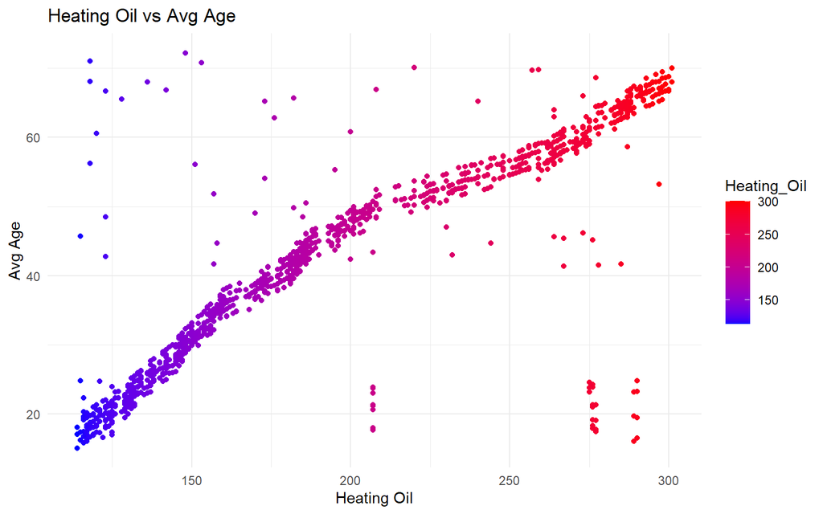

```r
ggplot(data, aes(x = Heating_Oil, y = Avg_Age, color = Heating_Oil)) +
  # Membuat objek grafik dengan data, menentukan sumbu X: Heating_Oil,
  # sumbu Y: Avg_Age, dan warna titik ditentukan oleh nilai Heating_Oil

  geom_point() +
  # Menambahkan layer berupa titik-titik (scatter plot)

  scale_color_gradient(low = "blue", high = "red") +
  # Memberi gradasi warna dari biru (nilai rendah) ke merah (nilai tinggi)
  # untuk menunjukkan tingkat konsumsi Heating_Oil

  theme_minimal() +
  # Menggunakan tema minimalis agar grafik tampak bersih dan profesional

  labs(
    title = "Heating Oil vs Avg Age",
    x = "Heating Oil",
    y = "Avg Age"
  )
```

```r
  # Memberi judul grafik dan label sumbu X dan Y
```

- Scatter plot di atas menunjukkan hubungan antara usia rata-rata penghuni rumah (Avg_Age) dan jumlah penggunaan minyak pemanas (Heating_Oil). Warna titik menunjukkan banyaknya konsumsi—semakin merah, semakin tinggi.
- Dari grafik, terlihat bahwa rumah dengan penghuni yang lebih tua cenderung menggunakan lebih banyak minyak pemanas. Ini menunjukkan bahwa usia bisa jadi faktor penting dalam kebiasaan penggunaan energi.
- Visualisasi ini membantu Sarah melihat apakah usia penghuni perlu dipertimbangkan dalam strategi pemasaran produk minyak pemanas.

## Langkah 4

## Scatter Plot Temperature vs Insulation

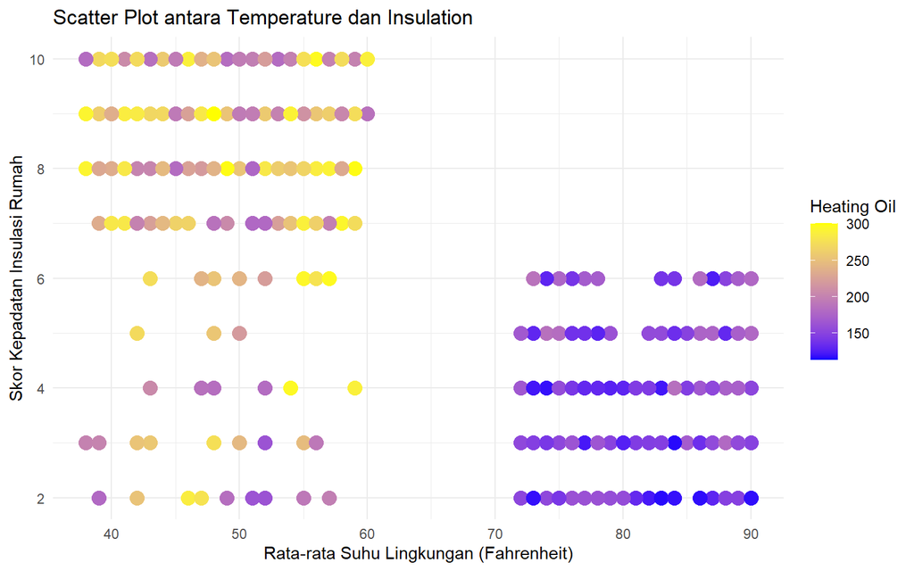

```r
ggplot(data, aes(x = Temperature, y = Insulation, color = Heating_Oil)) +
  # Membuat plot dengan sumbu X: Temperature (suhu lingkungan)
  # dan sumbu Y: Insulation (skor kepadatan isolasi rumah)
  # Warna titik menunjukkan nilai Heating_Oil (banyaknya minyak pemanas)

  geom_point(size = 4) +
  # Menambahkan titik pada plot (scatter plot), ukuran titik diperbesar agar lebih terlihat

  scale_color_gradient(low = "blue", high = "yellow") +
  # Memberikan gradasi warna dari biru (Heating_Oil rendah) ke kuning (Heating_Oil tinggi)

  labs(title = "Scatter Plot antara Temperature dan Insulation",
       x = "Rata-rata Suhu Lingkungan (Fahrenheit)",
       y = "Skor Kepadatan Insulasi Rumah",
       color = "Heating Oil") +
  # Menambahkan judul grafik, label sumbu X dan Y, serta label untuk legenda warna

  theme_minimal()
```

```r
  # Menggunakan tema minimal agar grafik tampak bersih dan profesional
```

## Langkah 5

# Soal II

## Tugas Sarah (Membuat & Menyimpan Model)

```r
# Menyiapkan Data
data <- read.csv("HeatingOil.csv")
head(data)
```

```
##   Insulation Temperature Heating_Oil Num_Occupants Avg_Age Home_Size
## 1          6          74         132             4    23.8         4
## 2         10          43         263             4    56.7         4
## 3          3          81         145             2    28.0         6
## 4          9          50         196             4    45.1         3
## 5          2          80         131             5    20.8         2
## 6          5          76         129             3    21.5         3
```

```r
# Membuat Model Regresi
model <- lm(Heating_Oil ~ Temperature + Insulation + Home_Size + Avg_Age +  Num_Occupants, data = data)
summary(model)
```

```
##
## Call:
## lm(formula = Heating_Oil ~ Temperature + Insulation + Home_Size +
##     Avg_Age + Num_Occupants, data = data)
##
## Residuals:
##      Min       1Q   Median       3Q      Max
## -103.558  -11.999    0.544   11.764  128.215
##
## Coefficients:
##                Estimate Std. Error t value Pr(>|t|)
## (Intercept)   135.48094    7.73091  17.525  < 2e-16 ***
## Temperature    -0.86993    0.07114 -12.228  < 2e-16 ***
## Insulation      3.32551    0.42044   7.910 5.78e-15 ***
## Home_Size       3.17151    0.31088  10.202  < 2e-16 ***
## Avg_Age         1.96582    0.06523  30.137  < 2e-16 ***
## Num_Occupants  -0.26896    0.40689  -0.661    0.509
## ---
## Signif. codes:  0 '***' 0.001 '**' 0.01 '*' 0.05 '.' 0.1 ' ' 1
##
## Residual standard error: 23.96 on 1212 degrees of freedom
## Multiple R-squared:  0.8193, Adjusted R-squared:  0.8186
## F-statistic:  1099 on 5 and 1212 DF,  p-value: < 2.2e-16
```

```r
# Menyimpan Model
saveRDS(model, file = "model_heatingoil.rds")
```

## Tugas Marketer (Memprediksi Data Baru)

```r
# Membaca Model
model_marketing <- readRDS("model_heatingoil.rds")

# Membaca Data Pelanggan Baru
data_marketing <- read.csv("HeatingOil-Marketing.csv")
head(data_marketing)
```

```
##   Insulation Temperature Num_Occupants Avg_Age Home_Size
## 1          6          74             4    23.8         4
## 2         10          43             4    56.7         4
## 3          3          81             2    28.0         6
## 4          9          50             4    45.1         3
```

```r
# Melakukan Prediksi
prediksi <- predict(model_marketing, newdata = data_marketing)

# Menampilkan Hasil
hasil <- cbind(data_marketing, Prediksi_Heating_Oil = prediksi)
print(head(hasil))
```

```
##   Insulation Temperature Num_Occupants Avg_Age Home_Size Prediksi_Heating_Oil
## 1          6          74             4    23.8         4             149.4560
## 2         10          43             4    56.7         4             254.4012
## 3          3          81             2    28.0         6             148.5274
## 4          9          50             4    45.1         3             219.0112
```

```r
# Membaca Model
model_marketing <- readRDS("model_heatingoil.rds")

# Membaca Data Pelanggan Baru
data_marketing <- read.csv("HeatingOil-Marketing.csv")

# Melakukan Prediksi
prediksi <- predict(model_marketing, newdata = data_marketing)

# Menampilkan Hasil
hasil <- cbind(data_marketing, Prediksi_Heating_Oil = prediksi)

# Memeriksa kolom yang ada di hasil
print(head(hasil))  # Menampilkan beberapa baris pertama dari hasil
```

```
##   Insulation Temperature Num_Occupants Avg_Age Home_Size Prediksi_Heating_Oil
## 1          6          74             4    23.8         4             149.4560
## 2         10          43             4    56.7         4             254.4012
## 3          3          81             2    28.0         6             148.5274
## 4          9          50             4    45.1         3             219.0112
```

```r
print(names(hasil))  # Menampilkan nama-nama kolom
```

```
## [1] "Insulation"           "Temperature"          "Num_Occupants"
## [4] "Avg_Age"              "Home_Size"            "Prediksi_Heating_Oil"
```